# Extending the Linear Model II

## Example: Truck prices

Can we use the age of a truck to predict what it's price should be? Consider a random sample of 43 pickup trucks.

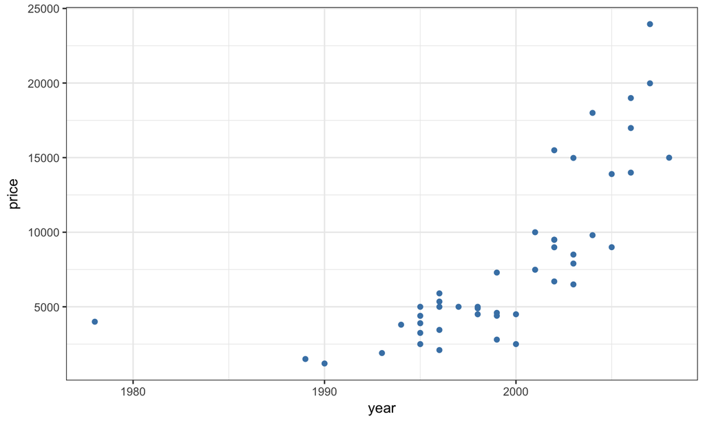

## Example: Truck prices

Can we use the age of a truck to predict what it's price should be? Consider a random sample of 43 pickup trucks *from the last 20 years*.

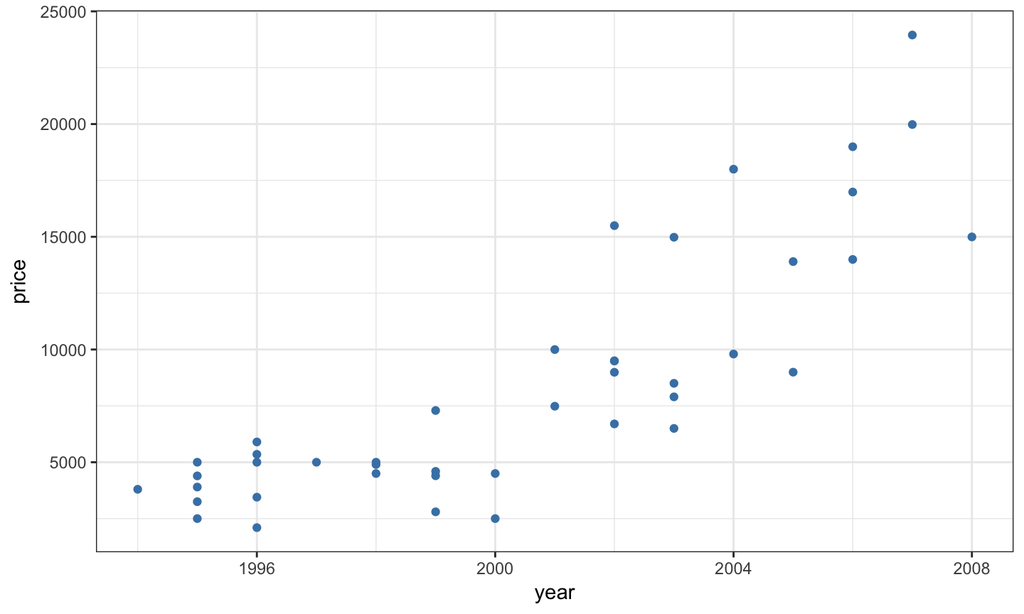

## Linear nodel?

```
##                 Estimate  Std. Error   t value     Pr(>|t|)
## (Intercept) -2278766.230 238325.6991 -9.561563 6.923503e-12
## year            1143.367    119.1371  9.597075 6.237638e-12
```

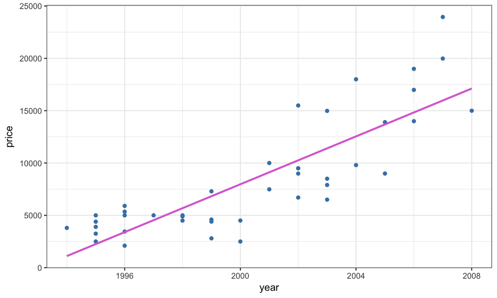

## Linearity and normality

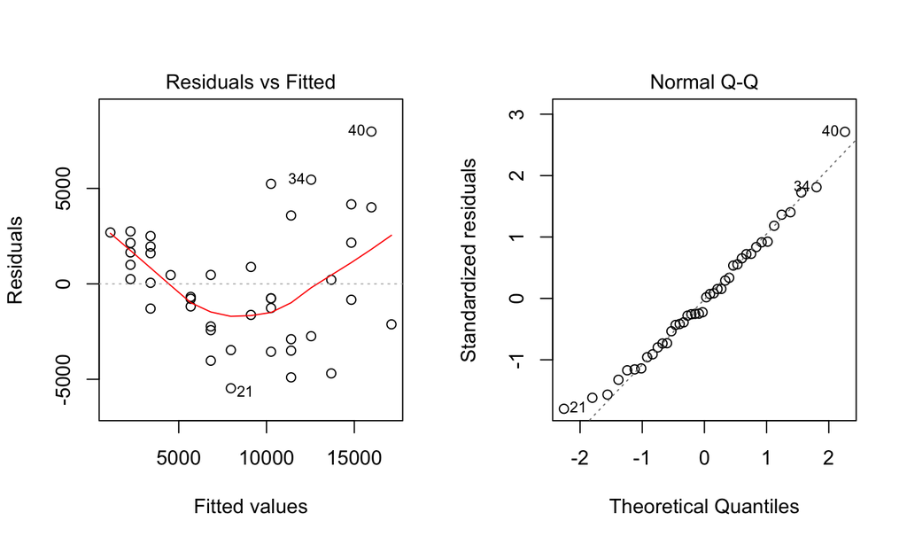

The normality assumption on the errors seems fine but there seems to be a quadratic trend in the mean function.

## Constant variance and influence

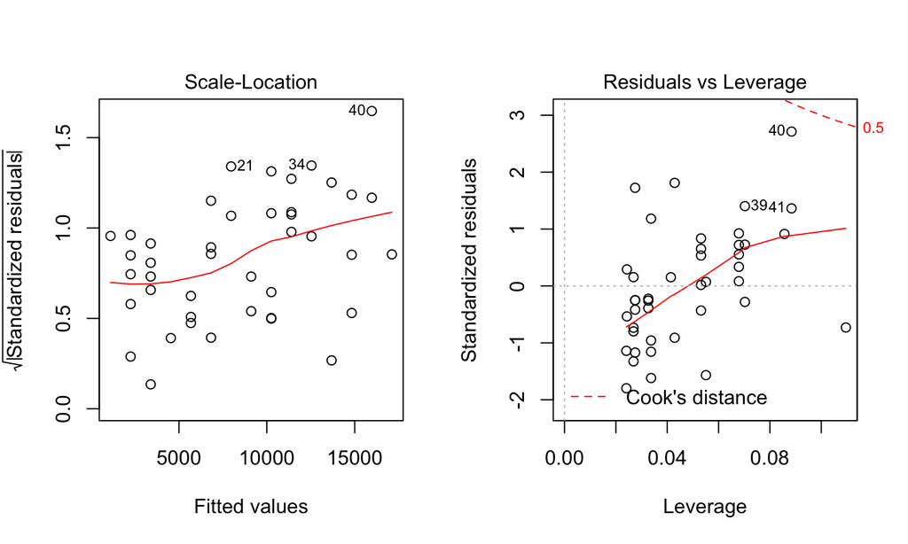

## Transformations

[figure not shown]

Say you fit a linear model to data and find the residual plots look awful. One strategy to regain a valid model is to transform your data.

```r
pickups <- mutate(pickups, log_price = log(price))
```

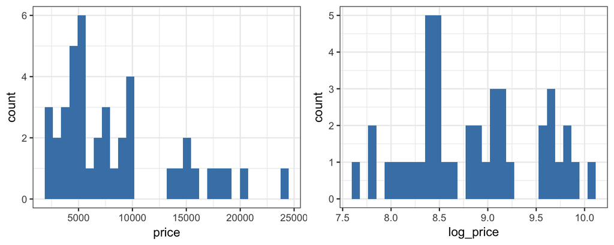

Variables that span multiple orders of magnitude often benefit from a natural log transformation.

\[ Y_t = log_e(Y) \]

## Log-transformed linear model

```
##                 Estimate  Std. Error   t value     Pr(>|t|)
## (Intercept) -258.9980504 26.12294226 -9.914582 2.471946e-12
## year           0.1338934  0.01305865 10.253239 9.342855e-13
```

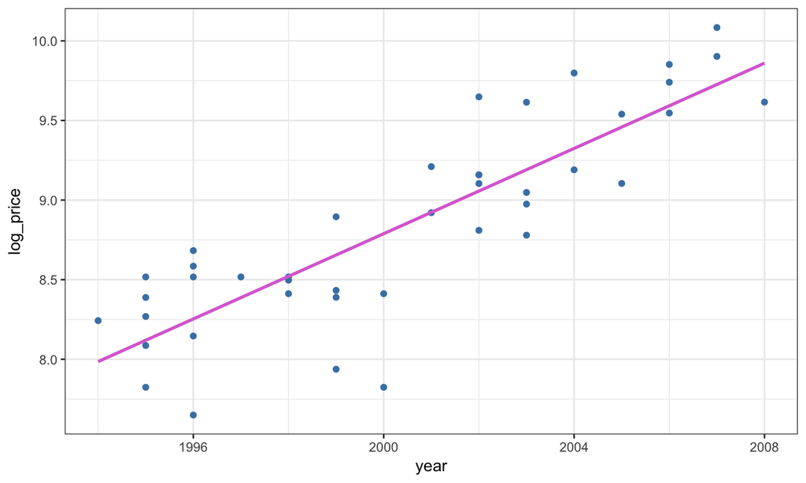

## Linearity and normality

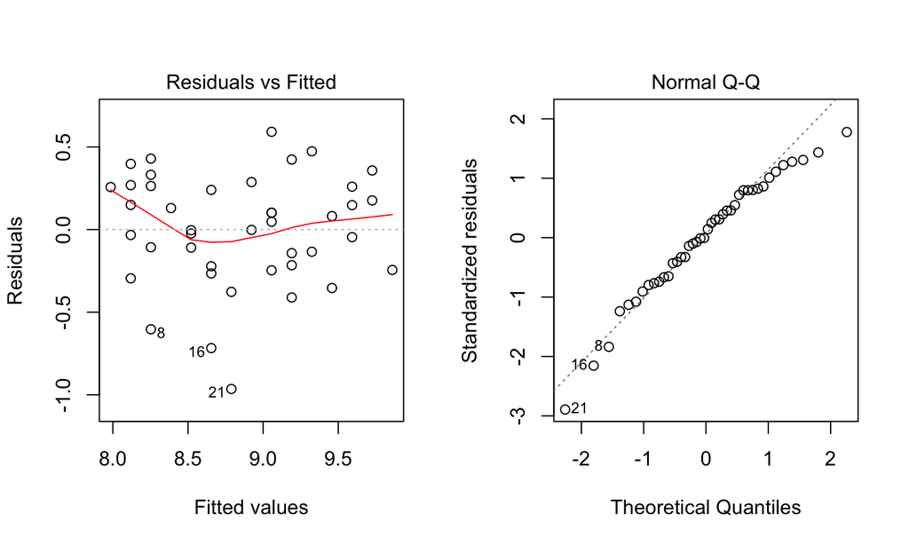

The residuals from this model appear less normal, though the quadratic trend in the mean function is now less apparent.

## Constant variance and influence

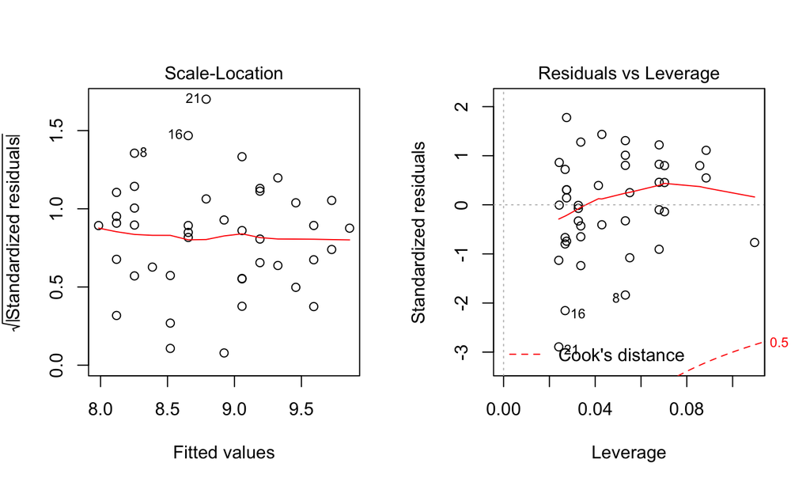

There are no points flagged as influential and our variance has been stabilized.

## Transformations summary

- If a linear model fit to the raw data leads to questionable residual plots, consider transformations.
- Count data and prices often benefit from transformations.
- The natural log and the square root are the most common, but you can use any transformation you like.
- Transformations may change model interpretations.
- Non-constant variance is a serious problem but it can often be solved by transforming the response.
- Transformations can also fix non-linearity, as can polynomials.